# Market Risk

### Iñaki Gangutia

The purpose of this project is to show how a **Stochastic Geometric Brownian Movement Process** can be applied to the finance sector, specifically to model Market Risk. As an example we will use the data related to the Standard & Poor’s 500 (S&P 500), the most common, famous and reference index to follow the United States Economy.

We will use this type of process to model the evolution of a random system through time with a non constant random variable, being the growth of this variable exponential and with a non constant volatility as the moment value increases.

To start we will load some packages needed for our project, each one with a purpose.

```python
import numpy as np
import pandas as pd
import matplotlib.pyplot as plt
from datetime import datetime
from scipy.stats import skew, kurtosis, norm

import yfinance as yf
```

We set the input variables to import the data.

```python
ticker = "^GSPC"  # S&P 500

current_date = datetime.today().strftime("%F")  # Last record
start_date = "2020-03-23"  # New cycle start (post-COVID19)
```

Now we will import our S&P 500 data from Yahoo as data provider.

```python
sp500_data = yf.download(ticker, start = start_date, end = current_date)
```

```
[*********************100%%**********************]  1 of 1 completed
```

In this part we will manipulate the obtained data selecting the Close column prices and we will ckeck our data head.

```python
sp500_prices = sp500_data["Close"]
print(sp500_prices.head())
```

```
Date
2020-03-23    2237.399902
2020-03-24    2447.330078
2020-03-25    2475.560059
2020-03-26    2630.070068
2020-03-27    2541.469971
Name: Close, dtype: float64
```

We proceed to convert the prices to logarithms and calculate the returns.

```python
log_returns = np.diff(np.log(sp500_prices))
```

Now we will get some needed historical parameters for the Euler method.

```python
S0 = sp500_prices.iloc[-1]  # Initial price
mu = np.mean(log_returns)  # Expected return (drift)
sigma = np.std(log_returns)  # Expected volatility
```

As it follows, we will set the rest of parameters for the Euler method.

```python
dt = 0.05  # Time step unit
T = 252  # Horizon Time (one trading year)
n_sim = int(T / dt)  # n simulations
n_tra = 1000  # n trajectories
```

### Euler method for Geometric Brownian Motion

This function will allow us to calculate various simulations and trajectories in base of the previous parameters. It is important to mention, that this method is an approximate numerical solution of the Stochastic Differential Equation (SDE).

```python
def GBM(S0, mu, sigma, dt, n_sim, n_tra):

    trajectories = []  # Trajectories storage

    # Iterate to generate trajectories
    for tra in range(n_tra):

        trajectory = np.full(n_sim + 1, np.nan)  # Current trajetory storage

        trajectory[0] = S0  # Set initial price


        # Iterate to calculate price changes
        for t in range(n_sim):

            # Euler Method
            Z = np.random.normal(0, 1)  # Standard normal random variable

            delta_S = mu * trajectory[t] * dt + sigma * trajectory[t] * np.sqrt(dt) * Z  # Delta S

            trajectory[t + 1] = trajectory[t] + delta_S  # Next price


        trajectories.append(trajectory)  # Add current trajectory


    return trajectories
```

Function call.

```python
simulations_trajectories = GBM(S0, mu, sigma, dt, n_sim, n_tra)
```

Next we will create a DataFrame to use all the data obtained from the previous simulations and trajectories.

```python
array_trajectories = np.array(simulations_trajectories)
time = np.arange(0, T + dt, dt)

trajectories_data = pd.DataFrame({"Trajectory": np.repeat(np.arange(n_tra), n_sim + 1),
                                  "Time": np.tile(time, n_tra),
                                  "Price": array_trajectories.flatten()})
```

Now we calculate the average trajectory that we will need later.

```python
average_trajectory = np.mean(array_trajectories, axis=0)
```

We calculate and show some descriptive statistics to know better the characteristics of our results.

```python
mean_price = round(np.mean(trajectories_data["Price"]), 2)
range_price = round(max(trajectories_data["Price"]) - min(trajectories_data["Price"]), 2)

variance = round(np.var(trajectories_data["Price"]), 2)
deviation = round(np.std(trajectories_data["Price"]), 2)

skewness = round(skew(trajectories_data["Price"]), 4)
kurtosis_val = round(kurtosis(trajectories_data["Price"]), 4)



Descriptive_Statistics = pd.DataFrame({"Mean": mean_price,
                                       "Range": range_price,
                                       "Variance": variance,
                                       "Standard_Deviation": deviation,
                                       "Skewness": skewness,
                                       "Kurtosis": kurtosis_val},
                                      index=["S&P 500"])

print(Descriptive_Statistics)
```

```
            Mean    Range   Variance  Standard_Deviation  Skewness  Kurtosis
S&P 500  6525.95  8534.05  920835.49               959.6     1.051    1.6024
```

The Value at Risk (VaR) is a measure that will quantify the maximum risk of loss of our active over a given period of time and with a specific confidence level.

```python
def VaR_func(alpha):

    last_values = array_trajectories[:, -1]
    var_value = np.quantile(last_values, alpha)
    VaR = round(S0 - var_value, 2)

    return VaR
```

The Conditional Value at Risk (CVaR) is a measure that provides an estimate of the expected value of losses in the worst case scenario, being the weighted average of losses exceeding VaR for the confidence level given.

```python
def CVaR_func(alpha):

    last_values = array_trajectories[:, -1]
    cvar_vec = last_values[last_values < np.quantile(last_values, alpha)]
    CVaR = round(S0 - np.mean(cvar_vec), 2)

    return CVaR
```

The Maximum Drawdown is the peak-to-trough decline in our active over a given period of time.

```python
def max_drawdown_func():

    max_drawdowns = []

    for trajectory in simulations_trajectories:

        peak = np.maximum.accumulate(trajectory)
        drawdowns = peak - trajectory
        max_drawdowns.append(max(drawdowns))

    max_aggregated = round(max(max_drawdowns), 2)

    return max_aggregated
```

Finally, we call the previous defined functions using an alpha of 0.01 or 1% and we create a data frame to show them together.

```python
alpha = 0.01 # 99% confidence interval

VaR = VaR_func(alpha)
CVaR = CVaR_func(alpha)

Risk_Measurement = pd.DataFrame({"VaR": VaR,
                                 "CVaR": CVaR,
                                 "Maximum_Drawdown": max_drawdown_func()},
                                index=["S&P 500"])

print(Risk_Measurement)
```

```
             VaR     CVaR  Maximum_Drawdown
S&P 500  1330.66  1519.78           2855.75
```

Next step is to create a data plot to appreciate visually our different trajectories and the final prices distribution.

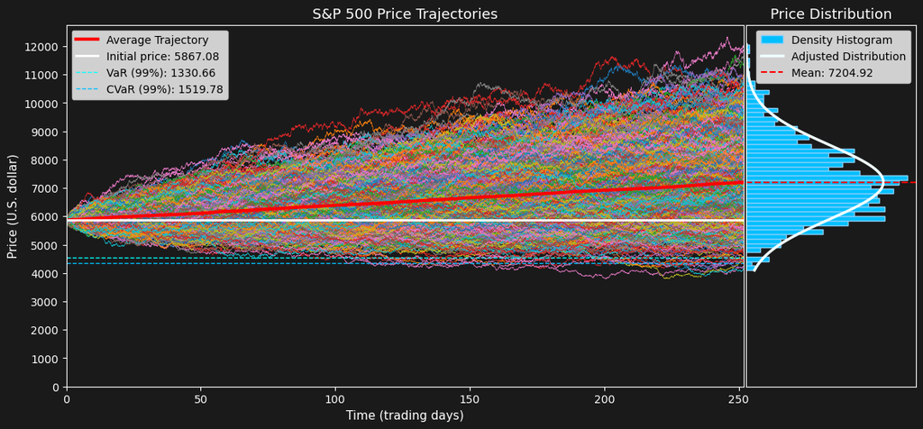

```python
fig, axs = plt.subplots(1, 2, figsize=(14, 6), gridspec_kw={'width_ratios': [4, 1]}, facecolor="#1A1A1A")


for tra in range(n_tra):
    trajectory_data = trajectories_data[trajectories_data["Trajectory"] == tra]
    axs[0].plot(trajectory_data["Time"], trajectory_data["Price"], linewidth=0.45)

axs[0].plot(time, average_trajectory, color="red", linewidth=3, label="Average Trajectory")
axs[0].axhline(S0, color="white", linestyle="solid", linewidth=2, label=f"Initial price: {np.round(S0, 2)}")

axs[0].axhline(-1 * (VaR - S0), color="aqua", linestyle="dashed", linewidth=1, label=f"VaR (99%): {VaR}")
axs[0].axhline(-1 * (CVaR - S0), color="deepskyblue", linestyle="dashed", linewidth=1, label=f"CVaR (99%): {CVaR}")

axs[0].set_xlim(min(trajectories_data["Time"]), max(trajectories_data["Time"]))
axs[0].set_facecolor("#1A1A1A")
axs[0].spines["bottom"].set_color("white")
axs[0].spines["top"].set_color("white")
axs[0].spines["right"].set_color("white")
axs[0].spines["left"].set_color("white")
axs[0].yaxis.label.set_color("white")
axs[0].xaxis.label.set_color("white")
axs[0].tick_params(axis="x", colors="white")
axs[0].tick_params(axis="y", colors="white")

y_max = int(max(trajectories_data["Price"]) * 1.05)
axs[0].set_yticks(np.arange(0, y_max, 1000))

axs[0].set_title("S&P 500 Price Trajectories", color="white", fontsize=13)
axs[0].set_xlabel("Time (trading days)", color="white", fontsize=11)
axs[0].set_ylabel("Price (U.S. dollar)", color="white", fontsize=11)
axs[0].legend()


final_data = trajectories_data[trajectories_data['Time'] == 252]['Price']
trajectories_flat = np.array(final_data)

mup, sigmap = norm.fit(trajectories_flat)
x = np.linspace(trajectories_flat.min(), trajectories_flat.max(), 1000)
p = norm.pdf(x, mup, sigmap)

axs[1].hist(trajectories_flat, bins=50, density=True, orientation='horizontal', color='deepskyblue', edgecolor='lightskyblue', label='Density Histogram')
axs[1].plot(p, x, linewidth=2.5, color='azure', label='Adjusted Distribution')
axs[1].axhline(mup, color='red', linestyle='--', label=f'Mean: {np.round(mup, 2)}')

axs[1].set_facecolor("#1A1A1A")
axs[1].spines["bottom"].set_color("white")
axs[1].spines["top"].set_color("white")
axs[1].spines["right"].set_color("white")
axs[1].spines["left"].set_color("white")
axs[1].yaxis.set_visible(False)
axs[1].xaxis.set_visible(False)
axs[1].set_yticks(np.arange(0, y_max, 250))

axs[1].set_xlabel('Densidad', color="white", fontsize=10)
axs[1].set_title('Price Distribution', color="white", fontsize=13)
axs[1].legend()


plt.subplots_adjust(wspace=0.005)
```

## References

Wilmott, P. (2006). *Paul Wilmott on Quantitative Finance*. John Wiley and Sons.

McKiney, W. (2017). *Python for Data Analysis*. O'Reilly Media.